# Recursos 17

9 actividades, nivelación

# Enunciado

Considere el proyecto cuyo cuadro de prelaciones, duraciones (semanas) y número de operarios necesarios por actividad se adjunta. Todas las actividades se han programado en su inicio más temprano.

1. Dibuje el diagrama de Gantt y el diagrama de cargas. ¿Cuál es el número máximo de operarios necesario y en qué semanas?

2. ¿Está nivelado el consumo de recursos? Calcule la suma de cuadrados de las cargas como medida de desnivel.

3. Nivele los recursos desplazando actividades no críticas dentro de su holgura, sin alargar el proyecto, con el algoritmo de mínimos cuadrados. Indique qué actividades desplaza y cuánto.

4. Compare el diagrama de cargas antes y después: máximo de operarios y suma de cuadrados.

Tabla 1: Cuadro de datos del enunciado

| activity | predecessor | duration | resources |
| --- | --- | --- | --- |
| A | --- | 3 | 3 |
| B | --- | 5 | 1 |
| C | --- | 4 | 1 |
| D | B | 6 | 4 |
| E | A,C | 3 | 1 |
| F | B,C | 2 | 4 |
| G | E,F | 4 | 3 |
| H | D | 5 | 2 |
| I | G,H | 4 | 3 |

# Resolución

## Apartado 1

1. Dibuje el diagrama de Gantt y el diagrama de cargas. ¿Cuál es el número máximo de operarios necesario y en qué semanas?

Cálculo de los tiempos tempranos y tardíos de los sucesos y de las holguras totales paso a paso. El primer paso muestra el grafo resuelto; a partir del siguiente se calcula desde el principio (avance con los botones):

[figure not shown]

paso 0 de 32

[figure not shown]

Figura 1: Grafo PERT con tiempos y camino crítico

Tabla 2: Calendario: fechas y holgura total de cada actividad

[figure not shown]

ninguna celda (0 de 72)

[figure not shown]

Haz clic en un número de la tabla para ver cómo se calcula.

👆 **Interactivo:** haz clic en cualquier celda de la tabla para ver cómo se calcula (otro clic la deselecciona), o usa los botones y las flechas del teclado.

| Actividad | Duración | Inicio más temprano | Fin más temprano | Inicio más tardío | Fin más tardío | H total | H libre | H independiente |
| --- | --- | --- | --- | --- | --- | --- | --- | --- |
| A | 3 | 0 | 3 | 6 | 9 | 6 | 1 | 1 |
| B | 5 | 0 | 5 | 0 | 5 | 0 | 0 | 0 |
| C | 4 | 0 | 4 | 5 | 9 | 5 | 0 | 0 |
| D | 6 | 5 | 11 | 5 | 11 | 0 | 0 | 0 |
| E | 3 | 4 | 7 | 9 | 12 | 5 | 0 | 0 |
| F | 2 | 5 | 7 | 10 | 12 | 5 | 0 | 0 |
| G | 4 | 7 | 11 | 12 | 16 | 5 | 5 | 0 |
| H | 5 | 11 | 16 | 11 | 16 | 0 | 0 | 0 |
| I | 4 | 16 | 20 | 16 | 20 | 0 | 0 | 0 |

En el Gantt cada actividad empieza en su inicio más temprano y la casilla lleva los operarios que ocupa; la fila *Total* suma la columna (carga de la semana) y la fila *Cuadrados* eleva cada carga al cuadrado (su suma, en la última columna, es la medida de desnivel que usa la nivelación).

[figure not shown]

Figura 2: Diagrama de Gantt con las cargas de operarios (inicios más tempranos)

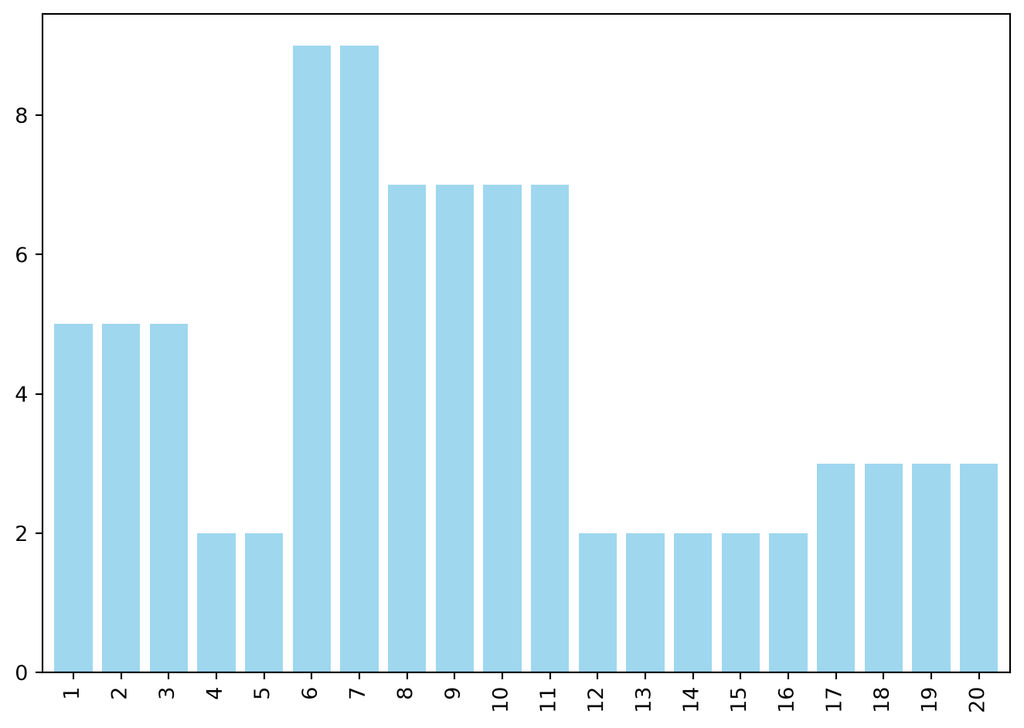

Figura 3: Diagrama de cargas de operarios

Cargas semana a semana: 5, 5, 5, 2, 2, 9, 9, 7, 7, 7, 7, 2, 2, 2, 2, 2, 3, 3, 3, 3 (total 87 operarios·semana en 20 semanas, media 87 / 20 = 4.35 operarios/semana).

**Respuesta:** el máximo es de **9 operarios**, en las semanas 6 y 7.

## Apartado 2

2. ¿Está nivelado el consumo de recursos? Calcule la suma de cuadrados de las cargas como medida de desnivel.

La suma de cuadrados de las cargas, $\sum_t c_t^2$, penaliza los picos: para una misma carga total es mínima cuando el perfil es plano (todas las semanas con la carga media). Es la función objetivo de la nivelación.

Σ c² = 7·2² + 4·3² + 3·5² + 4·7² + 2·9² = 28 + 36 + 75 + 196 + 162 = **497** (agrupando las semanas de igual carga).

Si los 87 operarios·semana se repartieran por igual en las 20 semanas, cada una tendría 4.35 y la suma sería 20 · 4.35² = 378.

**Respuesta:** no está nivelado: la carga va de 2 a 9 operarios y su suma de cuadrados es 497, 119 por encima de la de un perfil plano (378).

## Apartado 3

3. Nivele los recursos desplazando actividades no críticas dentro de su holgura, sin alargar el proyecto, con el algoritmo de mínimos cuadrados. Indique qué actividades desplaza y cuánto.

El algoritmo recorre las actividades no críticas (por orden de fin más temprano) y, para cada una, prueba todos los desplazamientos dentro de la holgura que le queda, eligiendo el que minimiza la suma de cuadrados (a igualdad, el menor desplazamiento).

Tabla 3: Actividades no críticas en el orden en que las recorre el algoritmo (fin más temprano creciente; a igualdad, más holgura primero)

| activity | A | C | E | F | G |
| --- | --- | --- | --- | --- | --- |
| inicio_mas_temprano | 0 | 0 | 4 | 5 | 7 |
| fin_mas_temprano | 3 | 4 | 7 | 7 | 11 |
| H_total | 6 | 5 | 5 | 5 | 5 |

Para cada una de ellas se prueba cada desplazamiento posible (las columnas de la tabla siguiente), se recalculan las cargas y su suma de cuadrados, y se aplica el desplazamiento de suma mínima (resaltado) antes de pasar a la siguiente actividad; por eso el resultado depende del orden y la holgura disponible puede ser menor que la del calendario inicial.

Tabla 4: Suma de cuadrados para cada desplazamiento posible

| activity | 0 | 1 | 2 | 3 | 4 | 5 | 6 |
| --- | --- | --- | --- | --- | --- | --- | --- |
| A | 497 | 497 | 485 | 501 | 517 | 523 | 495 |
| C | 485 | 491 | 485 | 473 | 461 | 457 |  |
| E | 457 |  |  |  |  |  |  |
| F | 457 | 441 |  |  |  |  |  |
| G | 441 |  |  |  |  |  |  |

- A (holgura total 6): se prueban 0 a 6; suma mínima 485 con 2 → se desplaza **2 semanas**

- C (holgura total 5): se prueban 0 a 5; suma mínima 457 con 5 → se desplaza **5 semanas**

- E (holgura total 5): solo puede probarse 0 (no 5: los desplazamientos ya aplicados a actividades que comparten su holgura le han dejado 0 semanas); suma mínima 457 con 0 → no se desplaza

- F (holgura total 5): se prueban 0 a 1 (no 5: los desplazamientos ya aplicados a actividades que comparten su holgura le han dejado 1 semana); suma mínima 441 con 1 → se desplaza **1 semana**

- G (holgura total 5): solo puede probarse 0 (no 5: los desplazamientos ya aplicados a actividades que comparten su holgura le han dejado 0 semanas); suma mínima 441 con 0 → no se desplaza

**Respuesta:** se desplazan A 2 semanas, C 5 semanas y F 1 semana, sin alargar el proyecto.

## Apartado 4

4. Compare el diagrama de cargas antes y después: máximo de operarios y suma de cuadrados.

[figure not shown]

Figura 4: Diagrama de Gantt tras la nivelación

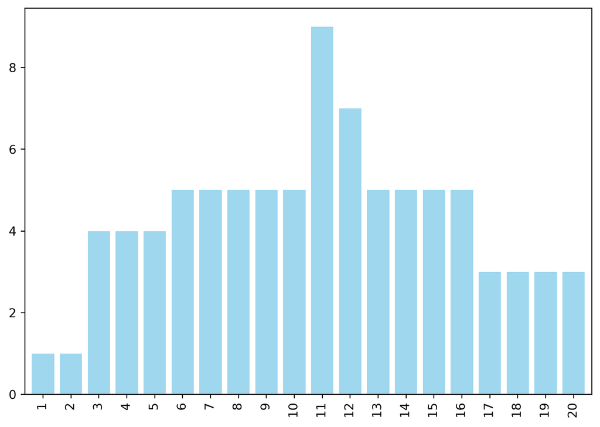

Figura 5: Diagrama de cargas tras la nivelación

|  | antes | después |
| --- | --- | --- |
| máximo de operarios | 9 | 9 |
| suma de cuadrados | 497 | 441 |
| duración | 20 | 20 |

Después de nivelar: Σ c² = 2·1² + 4·3² + 3·4² + 9·5² + 7² + 9² = 2 + 36 + 48 + 225 + 49 + 81 = **441**.

**Respuesta:** la suma de cuadrados baja de 497 a 441 (56 menos) y el máximo de operarios se mantiene en 9; la duración sigue siendo de 20 semanas porque solo se han movido actividades dentro de su holgura. El pico no baja: la nivelación minimiza la suma de cuadrados, no el máximo, y no ha encontrado desplazamientos que vacíen las semanas de carga máxima.